# 02477 Bayesian Machine Learning - Exercise 1

```python
%matplotlib inline
import pylab as plt
import jax.numpy as jnp
import seaborn as snb

from scipy.stats import binom as binom_dist
from scipy.stats import beta as beta_dist
from scipy.special import beta as beta_fun

snb.set_style('darkgrid')
snb.set(font_scale=1.5)
plt.rcParams['lines.linewidth'] = 3
```

## 📌 Maximum Likelihood Estimation

**Click to expand MLE derivation**

### Derivation:

$$ \hat{\theta}_{\text{MLE}} = \frac{y}{N} $$

## 🔍 Introduction and purpose of the first exercise

**Click to expand the introduction and purpose of the first exercise**

______

The purpose of this exercise is to become familiar with the core components of Bayesian inference:

> the **prior**, the **likelihood**, **posterior** and **the model evidence**.

We will also re-cap various ways to summarize distributions, e.g.

> **mean**, **mode**, **variance**, and **intervals**, and we will look into **how to compute and manipulate probabilities using sampling**.

We will study these concepts in the context of the **Beta-Binomial model**, which is the "Hello world"-equivalent of Bayesian statistics.

One of the main applications of the Beta-Binomial model is to **estimate proportions**. For example, suppose a website shows a specific ad to $N = 112$ customers and $y = 13$ of those costumers end up clicking on the ad. A common task is then to estimate the click-rate for this ad in order to answer questions like the following:

1. What is the probability that the next customer will click on the ad?
2. What is the probability that the click-rate is below 10%?
3. What is the probability that the click-rate is above 20%?

We will see how the Bayesian Beta-Binomial model can be used to answer such questions. Furthermore, we will conclude the exercise by studying a slightly more general version of the problem: Suppose a website has two ads: version A and version B and that version A was shown $N_A$ times and generated $y_A$ clicks, whereas version B was shown $N_B$ times and generated $y_B$ click. What is the probability that the click-rate of version B is larger than click-rate of version A?

### 📚 **Content**

- Part 1: Maximum likelihood estimation
- Part 2: Bayesian inference
- Part 3: The functional form of Beta distributions
- Part 4: Computing summary statistics and probabilities using sampling
- Part 5: Application to A/B testing

## 🧠 Estimating the proportions using the binomial distribution

In this exercise, we will work with two common families of probabilities distributions: the **Binomial distribution** and the **Beta distribution**.

**🔽 Summary of Binomial Distribution**

##### 📊 Binomial Distribution

The Binomial distribution gives the probability of observing exactly $y$ successes in $N$ independent Bernoulli trials, each with success probability $\theta$:

$$ p(y \mid N, \theta) = \binom{N}{y} \theta^y (1 - \theta)^{N - y} $$

- $N$: number of trials
- $y$: number of observed successes
- $\theta$: probability of success on a single trial
- $\binom{N}{y}$: binomial coefficient = $\frac{N!}{y!(N-y)!}$
- Mean of Binomial: $N\theta$
- Variance of Binomial: $N\theta(1 - \theta)$
- Mode of Binomial (when $N\theta$ is not an integer): $\lfloor N\theta \rfloor$ or $\lceil N\theta \rceil$ (whichever is closer to $N\theta$)
- The Binomial distribution is **conjugate** to the Beta distribution, meaning that if we have a prior belief about $\theta$ modeled as a Beta distribution, the posterior after observing data will also be a Beta distribution.

**🔽 Summary of Beta Distribution**

##### 🧪 Beta Distribution

The Beta distribution is a continuous distribution defined on the interval $[0, 1]$, commonly used as a **prior** for a probability parameter $\theta$:

$$ \text{Beta}(\theta \mid \alpha, \beta) = \frac{\Gamma(\alpha + \beta)}{\Gamma(\alpha)\Gamma(\beta)} \theta^{\alpha - 1} (1 - \theta)^{\beta - 1} $$

- $\alpha, \beta > 0$: shape parameters
- $\Gamma(\cdot)$: the Gamma function (generalization of factorial)
- Mean of Beta: $\frac{\alpha}{\alpha + \beta}$
- Mode of Beta (when $\alpha, \beta > 1$): $\frac{\alpha - 1}{\alpha + \beta - 2}$
- Variance: $\frac{\alpha \beta}{(\alpha + \beta)^2(\alpha + \beta + 1)}$

The Beta distribution is conjugate to the Binomial, which means: If $\theta \sim \text{Beta}(\alpha, \beta)$ and $y \sim \text{Binomial}(N, \theta)$ then the posterior is also a Beta:
$$\theta \mid y \sim \text{Beta}(\alpha + y, \beta + N - y)$$

## 📐 The Binomial Distribution and Maximum Likelihood Estimation

**Click to expand the introduction to the Binomial distribution**

The **Binomial distribution** models the number of **successes** in $N$ **independent** Bernoulli trials, where each trial has success probability $\theta$.

### 🔢 Definition

The probability mass function (PMF) is:

$$ \begin{align*} p(y|N, \theta) &= \text{Bin}(y|N, \theta) \\ &= {N \choose y} \theta^y (1 - \theta)^{N - y} \end{align*} $$

Where:

- $N$ = number of trials
- $y$ = number of observed successes, $y \in \left\lbrace 0, 1, \dots, N \right\rbrace$
- $\theta \in [0, 1]$ = probability of success per trial
- ${N \choose y}$ = *binomial coefficient*, pronounced “N choose y”  
  → counts how many ways $y$ items can be chosen from $N$

**📘 Click to expand: Deriving MLE for θ**

### ⚙️ Maximum Likelihood Estimation (MLE)

The **goal**: find $\theta$ that maximizes the probability of the data:

$$ \hat{\theta}_{\text{MLE}} = \arg\max_{\theta} p(y|N, \theta) $$

For the Binomial distribution, this has a **closed-form solution**:

$$ \hat{\theta}_{\text{MLE}} = \frac{y}{N} $$

### 📏 Confidence Interval (Frequentist)

You can compute a **95% confidence interval** for $\theta$ using a **Wald approximation**:

$$ \hat{\theta}_{\text{MLE}} \pm 1.96 \sqrt{\frac{\hat{\theta}_{\text{MLE}}(1 - \hat{\theta}_{\text{MLE}})}{N}} $$

💡 *This interval assumes approximate normality — it’s called the Wald interval.*

> ⚠️ **Note:** A **confidence interval** is *not the same* as a **Bayesian credibility interval**.  
> (See Murphy, Section 4.6.6 for more detail.)

## 📐 The Beta Distribution as a Prior for θ

**Click to expand the introduction to the Beta distribution**

The **Beta distribution** is a flexible prior over variables in the unit interval $[0,1]$. The PDF of the Beta distribution is defined by two shape parameters:

- $a_0 > 0$ and $b_0 > 0$

### 📘 Probability Density Function (PDF)

The PDF of the Beta distribution is:

$$ p(\theta \mid a_0, b_0) = \frac{1}{B(a_0, b_0)} \theta^{a_0 - 1}(1 - \theta)^{b_0 - 1} $$

Where:

- $\theta \in [0,1]$
- $B(a_0, b_0)$ is a **normalization constant** ensuring total probability = 1

**🔽 Click to expand: Normalization constant**

The normalization constant $B(a_0, b_0)$ is defined via the **Beta function**:

$$ B(a_0, b_0) = \int_0^1 \theta^{a_0 - 1}(1 - \theta)^{b_0 - 1} \, d\theta = \frac{\Gamma(a_0)\Gamma(b_0)}{\Gamma(a_0 + b_0)} $$

Here, $\Gamma(\cdot)$ is the **gamma function** — a generalization of factorial:  
$\Gamma(n) = (n - 1)!$ for positive integers.

🧠 *In practice, $B(a_0, b_0)$ is just a constant w.r.t. $\theta$.*

### 🧾 Functional Form

Since $B(a_0, b_0)$ is constant wrt. $\theta$, we often write:

$$ p(\theta \mid a_0, b_0) \propto \theta^{a_0 - 1}(1 - \theta)^{b_0 - 1} $$

> 🧩 This **functional form $f(\theta) = \theta^{a-1}(1-\theta)^{b-1}$ for some a,b > 0** makes the Beta distribution a **conjugate prior** for the Binomial.

### 📊 Summary Statistics

Let $\theta \sim \text{Beta}(a_0, b_0)$. Then:

- ✅ **Mean** (Expected value):

$$\mathbb{E}\left[\theta\right] = \int_0^1 \theta \, p(\theta|a_0,b_0) \,\text{d} \theta = \frac{a_0}{a_0+b_0}. \tag{1}$$

- ✅ **Variance**:

$$\mathbb{V}\left[\theta\right] = \int_0^1 \left(\theta - \mathbb{E}\left[\theta\right] \right)^2 \, p(\theta|a_0,b_0) \,\text{d} \theta = \frac{a_0 b_0}{(a_0+b_0)^2(a_0+b_0+1)}.$$

- ✅ **Mode** (when $a_0, b_0 > 1$):

  $$ \theta_{\text{mode}} = \frac{a_0 - 1}{a_0 + b_0 - 2} $$

> 💡 *The mode is the value of $\theta$ where the distribution peaks.*

### 📚 References

For more details:

- Murphy, Section 2.4.1
- Wikipedia articles:
  - [📘 Beta distribution](https://en.wikipedia.org/wiki/Beta_distribution)
  - [📘 Binomial distribution](https://en.wikipedia.org/wiki/Binomial_distribution)

## 📐 The Beta-Binomial Model

**Click to expand the introduction to the Beta-binomial model**

The **Beta-binomial model** is a classic **Bayesian model** for estimating proportions $\theta \in [0, 1]$.

- The **likelihood** is modeled with a **Binomial distribution**
- The **prior** for $\theta$ is a **Beta distribution**

### 📘 Model Definition

For a dataset $\mathcal{D} = \{N, y\}$, the model is defined as:

$$ \begin{align*} \text{Prior:} \quad & p(\theta) = \text{Beta}(\theta \mid a_0, b_0) \\ \text{Likelihood:} \quad & p(y \mid \theta) = \binom{N}{y} \theta^y (1 - \theta)^{N - y} \\ \text{Posterior:} \quad & p(\theta \mid y) = \text{Beta}(\theta \mid a_0 + y, b_0 + N - y) \end{align*} $$

### 🔠 Notation Notes

> 💡 We follow Murphy’s book conventions throughout.
- $p(\theta)$ = **prior**, sometimes written as $p(\theta \mid a_0, b_0)$ when emphasizing hyperparameters
- $p(y \mid \theta)$ = **likelihood**, based on Binomial distribution
- $p(\theta \mid y)$ or $p(\theta \mid \mathcal{D})$ = **posterior**, after observing $y$ out of $N$
- $\theta$ = model **parameter**
- $a_0, b_0$ = **hyperparameters** of the Beta prior

**🔽 Click to expand: Full posterior expression**

The posterior is analytically tractable because of conjugacy:  
A Beta prior and a Binomial likelihood yield a **Beta posterior**:

$$ p(\theta \mid y) = \text{Beta}(\theta \mid a_0 + y, \; b_0 + N - y) $$

🧠 This means we can **update beliefs** about $\theta$ simply by **adding successes/failures** to prior counts.

### 🧩 Summary

- **Prior**: Beta-distributed belief about $\theta$ before observing data
- **Likelihood**: Binomial process generating $y$ successes in $N$ trials
- **Posterior**: Updated Beta distribution after observing $y$

This is a cornerstone of Bayesian inference and provides a closed-form, interpretable update rule.

________________________

# 🎯 Part 1: Maximum Likelihood Estimation

Suppose we observe:

- $N = 7$ independent Bernoulli trials
- $y = 1$ success

Then our dataset is: $\mathcal{D} = \{ N = 7,\; y = 1 \}$

We want to estimate the **probability of success** $\theta \in [0, 1]$ using **maximum likelihood**.

##### 📝 Task 1.1

🔍 **Plot the likelihood** $p(y \mid \theta)$ as a function of $\theta$ over the interval $[0, 1]$.

🎯 **Goal**: Identify the **maximum likelihood estimate** (MLE) visually **and/or** numerically.

### 💡 Hints

- You can **implement the likelihood manually** using:

  $$ p(y \mid \theta) = \binom{N}{y} \theta^y (1 - \theta)^{N - y} $$
- Or you can use **SciPy's built-in function**:

  ```
  from scipy.stats import binom
  binom.pmf(y, n, p)
  ```

When computing the likelihood, we assume that $y$ and $N$ are fixed, and we vary $\theta$. So we write: $$\mathcal{L}(\theta) = p(y \mid \theta) = p(y| N = 7, \theta) = \binom{7}{1} \theta^1 (1 - \theta)^{7 - 1}$$

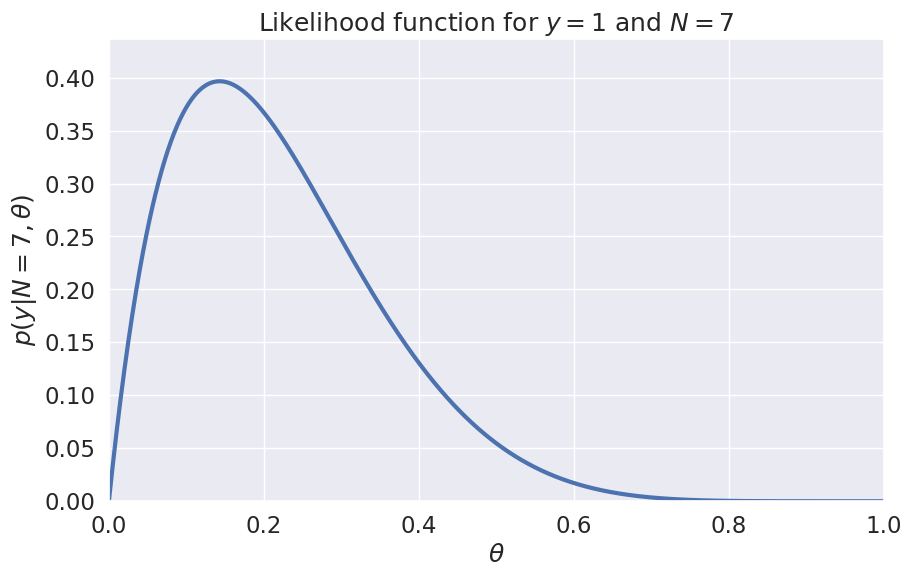

```python
from scipy.stats import binom

# data
N1 = 7
y1 = 1

# make grid for plotting the likelihood p(y|theta) in interval [0, 1]
thetas = jnp.linspace(0, 1, 1000)

def built_in_fun(y, n, p):
    return binom.pmf(y, n, p)

likelihood = built_in_fun(y1, N1, thetas)

fig, ax = plt.subplots(1,1, figsize=(10, 6))
ax.plot(thetas, likelihood)
plt.ylabel(r'$p(y|N=7, \theta)$')
plt.xlabel(r'$\theta$')
plt.title('Likelihood function for $y=1$ and $N=7$')
plt.xlim(0, 1)
plt.ylim(0, 1.1 * jnp.max(likelihood))
plt.show()
```

##### 📝 **Task 1.2**: Compute the maximum likelihood estimate for $\theta$ and compute a 95% confidence interval using the equations given above.

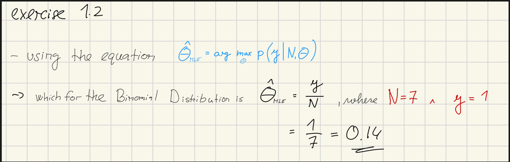

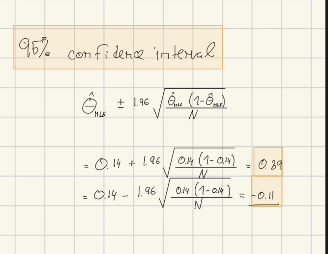

```
The MLE estimate of the Binomial Distribution is 0.143
Upper 95: 0.402, Lower 95: -0.116
```

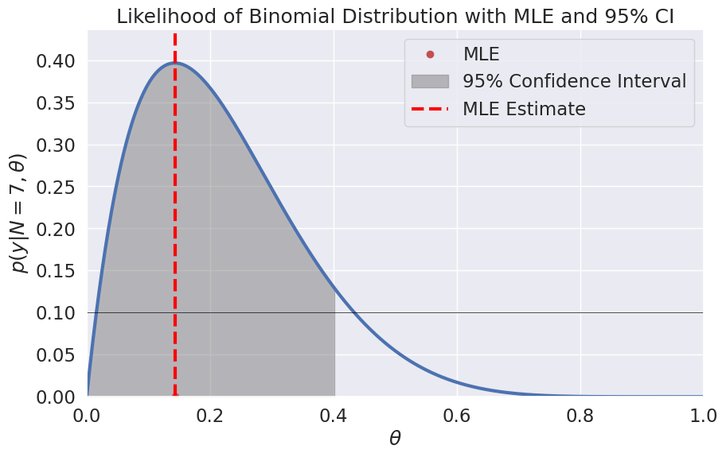

```python
def MLE_esetimate(y, N):
    return y/N

mle_binom = MLE_esetimate(y1, N1)

print(f"The MLE estimate of the Binomial Distribution is {mle_binom:.3f}")


def conf95(MLE, N):
    fraction = 1.96 * jnp.sqrt(((MLE * (1 - MLE)) / (N)))
    return MLE + fraction, MLE - fraction

upper, lower = conf95(mle_binom, N1)

print(f"Upper 95: {upper:.3f}, Lower 95: {lower:.3f}")




fig, ax = plt.subplots(1,1, figsize=(10, 6))
ax.plot(thetas, likelihood)
ax.plot(mle_binom, likelihood[0], 'ro', label='MLE')
ax.fill_between(thetas, likelihood, where=(thetas >= lower) & (thetas <= upper),
                 color='gray', alpha=0.5, label='95% Confidence Interval')
ax.legend()
plt.title('Likelihood of Binomial Distribution with MLE and 95% CI')
plt.xlim(0, 1)
plt.ylim(0, 1.1 * jnp.max(likelihood))
plt.axvline(mle_binom, color='red', linestyle='--', label='MLE Estimate')
plt.axhline(0, color='black', lw=0.5)
plt.axhline(1, color='black', lw=0.5)
plt.axhline(0.5, color='black', lw=0.5)
plt.axhline(0.1, color='black', lw=0.5)
plt.axhline(0.9, color='black', lw=0.5)
plt.legend()
plt.ylabel(r'$p(y|N=7, \theta)$')
plt.xlabel(r'$\theta$')
plt.show()
```

##### 🧾 **Task 1.3**: What happens if you had observed $y = 0$ instead of $y = 1$? Does the result seem reasonable?

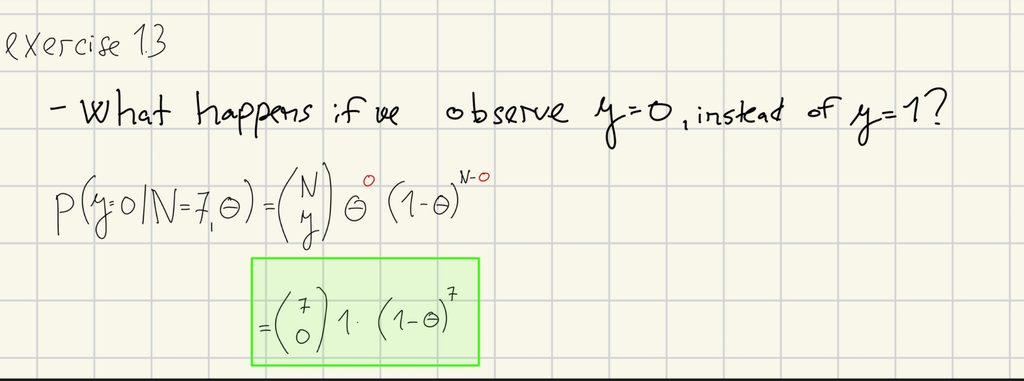

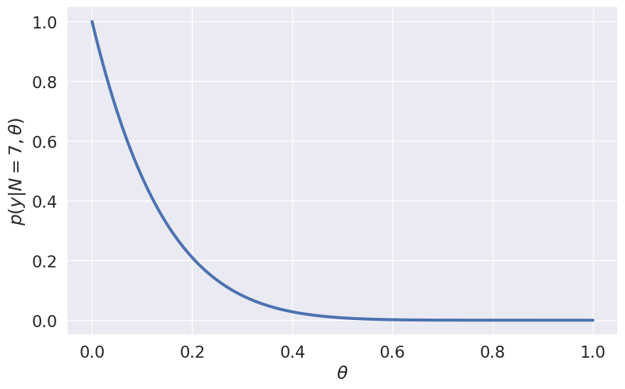

```python
from scipy.stats import binom

# data
N3 = 7
y3 = 0

# make grid for plotting the likelihood p(y|theta) in interval [0, 1]
thetas = jnp.linspace(0, 1, 1000)

def built_in_fun(y, n, p):
    return binom.pmf(y, n, p)

likelihood = built_in_fun(y3, N3, thetas)

fig, ax = plt.subplots(1,1, figsize=(10, 6))
ax.plot(thetas, likelihood)
plt.ylabel(r'$p(y|N=7, \theta)$')
plt.xlabel(r'$\theta$')
plt.show()
```

🧠 We observe 0 successes out of 7 trials, which means that the MLE is at $\hat{\theta}_{\text{MLE}} = 0$.

- As $\theta$ increases, the probability of observing 0 successes becomes **smaller**, becase we are assuming that success is more likely, but non occured.
- The curve $\mathcal{L}(\theta) = (1-\theta)^7$ is **strictly decreasing** in the interval $[0, 1]$.
- If no successes were observed out ot 7 trials, the most likely explanation under the binomial model is that the probability of success $\theta$ is 0. As $\theta$ increases, the model expects more successes, but we have not observed any. Thus, the model assigns a lower probability to larger values of $\theta$.

# 🎯 Part 2: Bayesian inference

We will now turn our attention towards Bayesian inference for $\theta$. Recall, the core concept of Bayesian inference is that we infer a **full probability distribution** for $\theta$ rather than just a **point estimate** like $\hat{\theta}_{MLE}$. As before, your dataset is given by $\mathcal{D} = \left\lbrace N = 7, y = 1\right\rbrace$, but now we assume a **uniform prior distribution** for $\theta$, i.e. $p(\theta) = \text{Beta}(\theta|a_0,b_0) = 1$ for $a_0 = b_0 = 1$.

##### 🧾 **Task 2.1**: Compute the **prior** mean and variance of $\theta$, i.e. the mean and variance of $p(\theta)$.

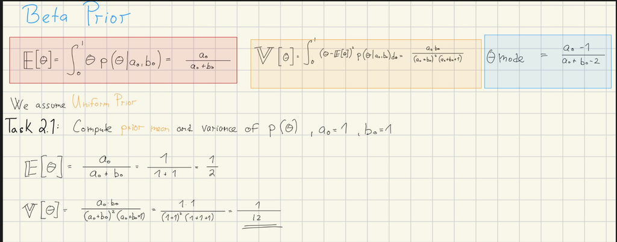

```python
# prior parameters

a_0 = 1
b_0 = 1

def prior_and_post_mean(a, b):
    return a / (a + b)


def prior_variance(a, b):
    return a * b / ( (a + b)**2 * (a + b + 1) )

prior_mean = prior_and_post_mean(a_0, b_0)
prior_variance = prior_variance(a_0, b_0)

print(f"Prior mean: {prior_mean:.3f}, Prior variance: {prior_variance:.3f}")
```

```
Prior mean: 0.500, Prior variance: 0.083
```

##### 🧾 **Task 2.2**: Compute the parameters $a$ and $b$ of the posterior distribution, i.e. $p(\theta|y)$, using the equations for the Beta-binomial model.

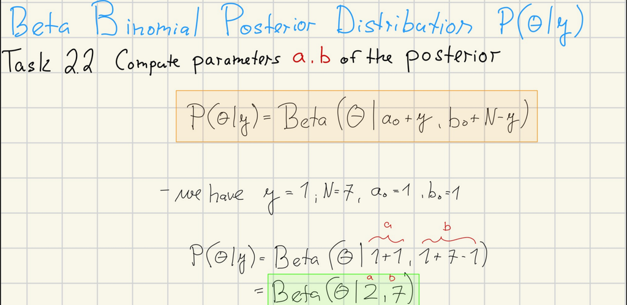

##### 🧾 **Task 2.3**: Plot the prior density $p(\theta)$, likelihood $p(y|\theta)$, and the posterior density $p(\theta|y)$ as a function of $\theta$ for $\theta \in \left[0, 1\right]$ in the same figure.

*Hints: the functions beta_dist.pdf and binom_dist.pmf might come in handy*

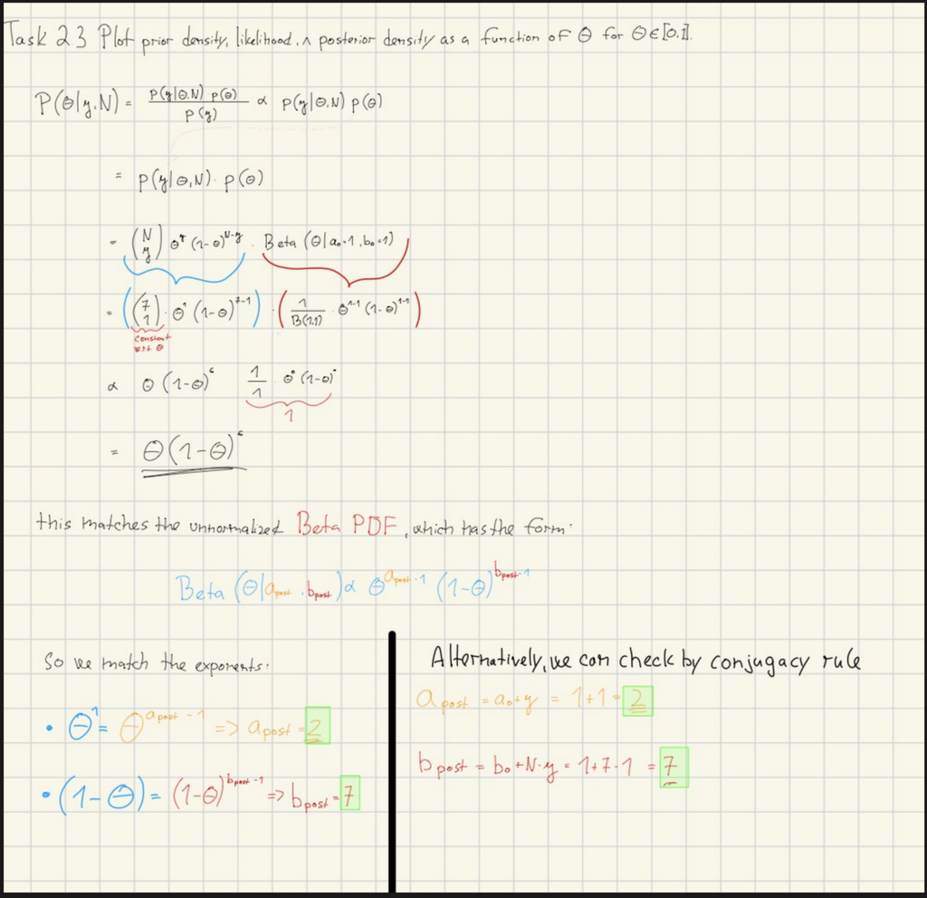

```
Posterior a: 2.000
Posterior b: 7.000
```

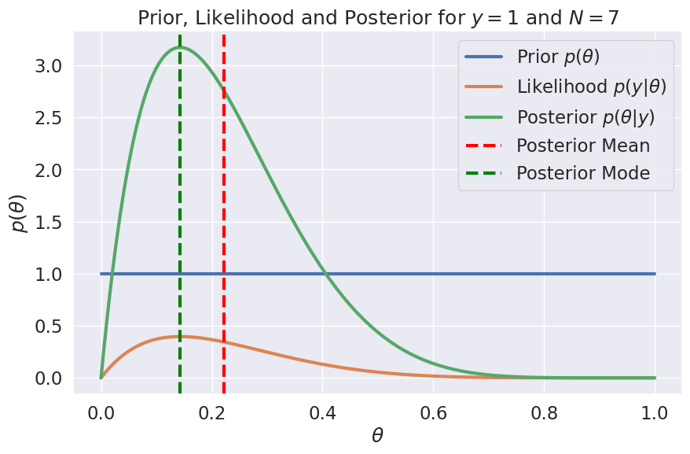

```python
prior = beta_dist.pdf(thetas, a_0, b_0)

likelihood = built_in_fun(y1, N1, thetas)


a_post = a_0 + y1
print(f"Posterior a: {a_post:.3f}")
b_post = b_0 + N1 - y1
print(f"Posterior b: {b_post:.3f}")

posterior = beta_dist.pdf(thetas, a_post, b_post)


# done in hand

#import numpy as np
#unnormalized_posterior = likelihood * prior
#posterior = unnormalized_posterior / np.trapz(unnormalized_posterior, thetas)  # Normalize using trapezoidal rule

# plot

fig, ax = plt.subplots(1,1, figsize=(10, 6))
ax.plot(thetas, prior, label=r'Prior $p(\theta)$')
ax.plot(thetas, likelihood, label=r'Likelihood $p(y|\theta)$')
ax.plot(thetas, posterior, label=r'Posterior $p(\theta|y)$')
plt.ylabel(r'$p(\theta)$')
plt.xlabel(r'$\theta$')
post_mean = prior_and_post_mean(a_post, b_post)
ax.axvline(post_mean, color='red', linestyle='--', label='Posterior Mean')
post_mode = (a_post - 1) / (a_post + b_post - 2)
ax.axvline(post_mode, color='green', linestyle='--', label='Posterior Mode')
plt.title('Prior, Likelihood and Posterior for $y=1$ and $N=7$')
plt.legend()
plt.show()
```

##### 🧾 **Task 2.4**: Compute the **MAP-estimator** for $\theta$ as well as the posterior mean of $\theta$.

*Hint*: *The MAP-estimator is the mode of the posterior density, i.e. $\theta_{\text{MAP}} = \arg\max\limits_{\theta \in \left[0, 1\right]} p(\theta|y)$*, and can be computed analytically for the Beta-binomoial model.

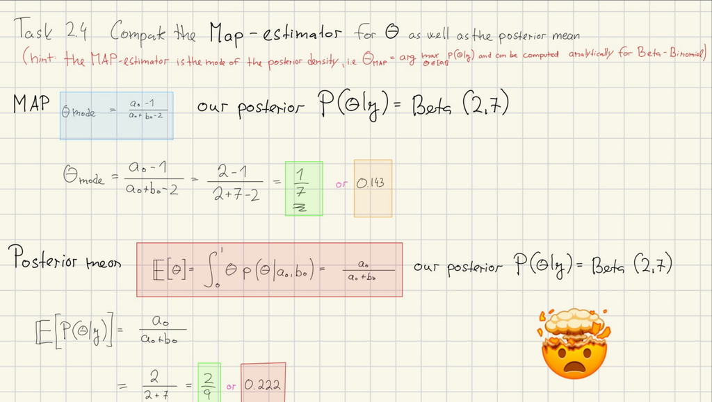

```python
post_mean = prior_and_post_mean(a_post, b_post)

print(f"Posterior mean: {post_mean}")

def post_mode(a, b):
    return (a - 1) / (a + b - 2)

print("*" * 40)

post_mode = post_mode(a_post, b_post)
print(f"Posterior mode: {post_mode:.3f}")
```

[output not shown]

##### 🧾 **Task 2.5**: Compute a 50%, 90% and a 95% posterior credibility interval for $\theta$.

*Hints*:

- To obtain a 50% posterior credibility interval, our goal is to identify $\theta_1, \theta_2 \in \left[0, 1\right]$ such that $p(\theta \in \left[\theta_1, \theta_2\right]|\mathcal{D}) = \int _{\theta_1}^{\theta_2} p(\theta|\mathcal{D}) \text{d} \theta \approx 0.5$
- *scipy.stats.beta.interval* might come in handy for this.

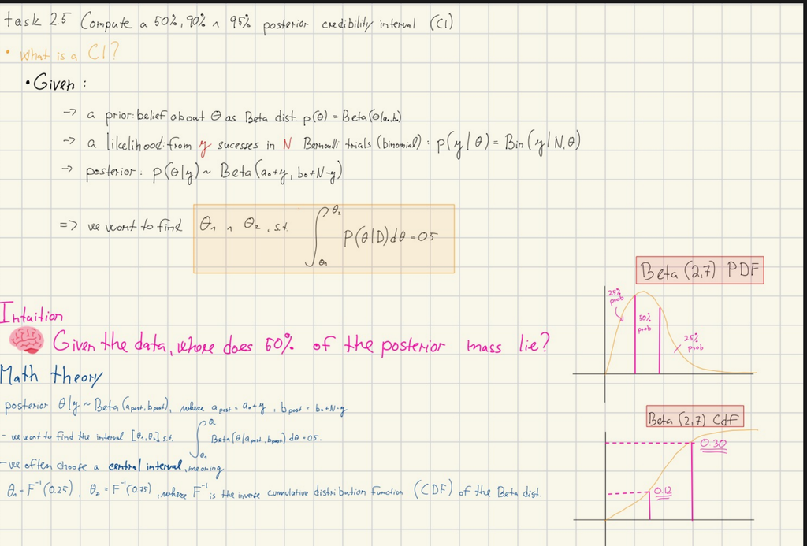

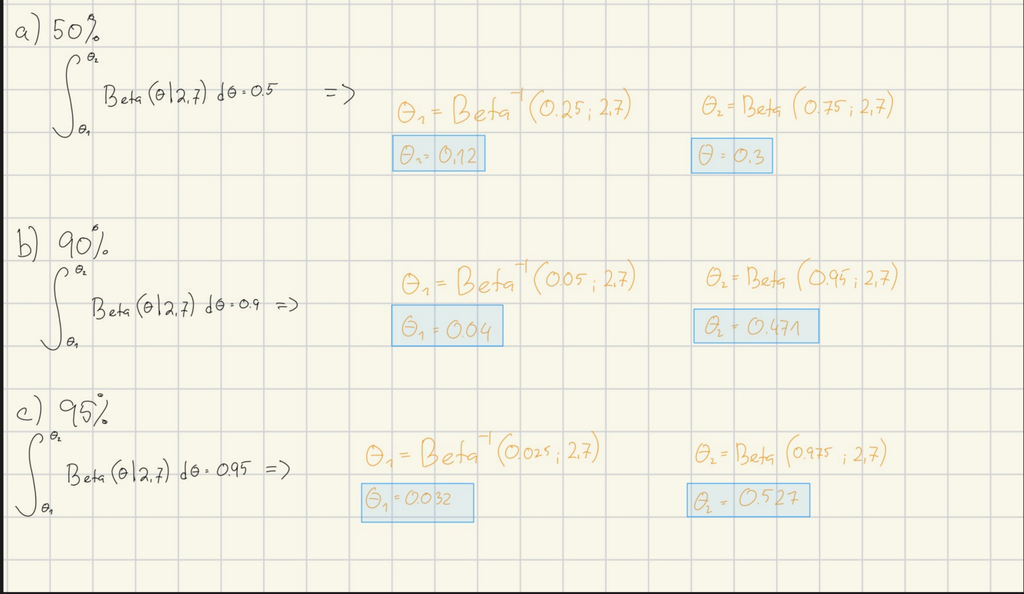

```python
from scipy.stats import beta

intervals = [0.5, 0.9, 0.95]

for alpha in intervals:
    cred_interval = beta.interval(alpha, a_post, b_post)
    lower = float(cred_interval[0])
    upper = float(cred_interval[1])
    print(f"{int(alpha * 100)}% credible interval: ({lower:.3f}, {upper:.3f})")
```

```
50% credible interval: (0.121, 0.303)
90% credible interval: (0.046, 0.471)
95% credible interval: (0.032, 0.527)
```

##### 🔍 We can use also `beta.ppf` to find the credible intervals.

- For example in 50% credible interval, we want a lower bound: 25th percentile and an upper bound: 75th percentile.
- For 90% credible interval, we want a lower bound: 5th percentile and an upper bound: 95th percentile.
- For 95% credible interval, we want a lower bound: 2.5th percentile and an upper bound: 97.5th percentile.

```python
percentiles = [[0.25, 0.75], [0.05, 0.95], [0.025, 0.975]]

for lower_q, upper_q in percentiles:
    lower = beta.ppf(lower_q, a_post, b_post)
    upper = beta.ppf(upper_q, a_post, b_post)
    level = int((upper_q - lower_q) * 100)
    print(f"{level}% credible interval: ({lower:.3f}, {upper:.3f})")
```

```
50% credible interval: (0.121, 0.303)
89% credible interval: (0.046, 0.471)
95% credible interval: (0.032, 0.527)
```

##### 🧾 **Task 2.6**: What happens if you had observed $y = 0$ instead of $y = 1$? Does the result seem reasonable?

**Note**: *This is a discussion question, which means that you actively have to experiment with the code and/or reason with the equations to arrive at the relevant conclusions. This also means that we won't provide a specific solution for this task. However, you are more than welcome to check your understanding and your conclusions with the TAs.*

```
Posterior a: 1.000
Posterior b: 8.000
```

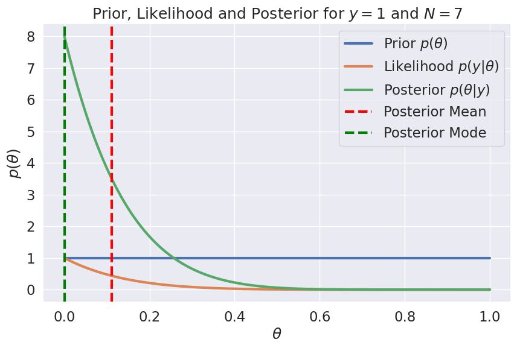

```python
prior = beta_dist.pdf(thetas, a_0, b_0)

likelihood = built_in_fun(0, N1, thetas)


a_post = a_0 + 0
print(f"Posterior a: {a_post:.3f}")
b_post = b_0 + N1 - 0
print(f"Posterior b: {b_post:.3f}")

posterior = beta_dist.pdf(thetas, a_post, b_post)


# done in hand

#import numpy as np
#unnormalized_posterior = likelihood * prior
#posterior = unnormalized_posterior / np.trapz(unnormalized_posterior, thetas)  # Normalize using trapezoidal rule

# plot

fig, ax = plt.subplots(1,1, figsize=(10, 6))
ax.plot(thetas, prior, label=r'Prior $p(\theta)$')
ax.plot(thetas, likelihood, label=r'Likelihood $p(y|\theta)$')
ax.plot(thetas, posterior, label=r'Posterior $p(\theta|y)$')
plt.ylabel(r'$p(\theta)$')
plt.xlabel(r'$\theta$')
post_mean = prior_and_post_mean(a_post, b_post)
ax.axvline(post_mean, color='red', linestyle='--', label='Posterior Mean')
post_mode = (a_post - 1) / (a_post + b_post - 2)
ax.axvline(post_mode, color='green', linestyle='--', label='Posterior Mode')
plt.title('Prior, Likelihood and Posterior for $y=1$ and $N=7$')
plt.legend()
plt.show()
```

🔎 Performing 7 Bernoulli trials and observing 0 successes $y=0$, it tells us that the underlying success probability $$\theta$$ is very likely to be 0, since we have not observed any successes.

- That is the same as flipping a biased coin 7 times and observing 0 heads, which would also suggest that the coin is likely biased towards tails.
- Therefore, the posterior should shift towardd smaller values of $\theta$ and favouring those around $\theta = 0$.
- Since we have uniform prior and observe 0 successes, the update will shift the posterior towards smaller values of $\theta$, which is consistent with the observations.

More closely,

- The prior is saying that all values of $\theta$ are equally likely.
- The likelihood is saying that the probability of observing 0 successes is highest when $\theta$ is close to 0.
- The posterior combines these two, resulting in a distribution that is skewed towards 0.
- As we collect more data, the posterior will become more concentrated around the true value of $\theta$, which in this case is likely to be 0.

##### 🧾 **Task 2.7**: Experiment with different values of $a_0$, $b_0$, $N$, and $y$ to explore how it affects the results (e.g. the plots, MAP, posterior mean and posterior credibility interval).

**Note**: *This is a discussion question, which means that you actively have to experiment with the code and/or reason with the equations to arrive at the relevant conclusions. This also means that we won't provide a specific solution for this task. However, you are more than welcome to check your understanding and your conclusions with the TAs.*

In the next few tasks, we will explore the relationships between the posterior mean and the maximum likelihood estimator.

##### 🧾 **Task 2.8** Show that the posterior mean converges to the maximum likelihood estimator $\hat{\theta}_{\text{MLE}} = \frac{y}{N}$ as $N \rightarrow \infty$.

*Hints:*

- *Write the posterior mean as a function of $a_0, b_0, N, y$*
- *Write the number of successes as $y = \hat{\theta}_{MLE} N$ and substitute it into the expression for the posterior mean*
- *If you are stuck, don't hesitate to consult the solution or ask the teachers/teaching assistant for an additional hint*

##### 🧾 **Task 2.9** Show that the posterior mean is always between the prior mean, $\theta_0 = \frac{a_0}{a_0 + b_0}$, and the maximum likelihood estimate $\hat{\theta}_{MLE} = \frac{y}{N}$.

Hints:

- Show that the posterior mean is a convex combination of the prior mean $\theta_0$ and the maximum likelihood solution $\hat{\theta}_{\text{MLE}}$, i.e. that the posterior mean can be written as

$$ \begin{align*} \mathbb{E}\left[\theta|\mathcal{D}\right] = (1-\lambda) \theta_0 + \lambda \hat{\theta}_{MLE} \end{align*} $$ for some $0 \leq \lambda \leq 1$.

# 🎯 Part 3: The functional form of Beta distributions

Suppose you are given the expression for a probability density function $p_d(\theta)$ up to a constant, i.e. you are told that $p_d(\theta) = \frac{1}{Z_d}\theta^{36}(1-\theta)^{41}$, where $Z_d > 0$ is an unknown, but positive constant.

**Task 3.1**: Argue the distribution $p_d$ specified above must be a Beta-distribution $p(\theta|a_d, b_d)$ and identify its parameters $a_d, b_d$.

**Task 3.2**: Compute $Z_d$

*Hint: What is the normalization constant for a Beta distribution?*

```python
from scipy.special import beta


a_d = 37
b_d = 42

Zd = beta(a_d, b_d)

print(f"The normalization constant Zd given by Beta({a_d}, {b_d}) is: {Zd}")
```

```
The normalization constant Zd given by Beta(37, 42) is: 1.0988879972626741e-24
```

We will now use our knowledge of the functional form for Beta densities to compute the denominator in Bayes' theorem, $p(y)$, which is often called the **model evidence** or the **marginal likelihood**. It can be expressed using the **product rule** and the **sum rule** of probability theory:

$$\begin{align*} p(y) = \underbrace{\int p(y, \theta) \text{d}\theta}_{\text{sum rule}} = \int \underbrace{p(y|\theta)p(\theta)}_{\text{product rule}} \text{d}\theta . \end{align*} $$

Later in the course, we will see that this term can be useful for hyperparameter tuning and model selection. For most models of practical interest, the term will be **intractable** because we cannot solve the integral above analytically. However, for models like the beta-binomial we actually compute this term in closed-form.

**Task 3.3**: Compute the analytical expression for the model evidence for the Beta-Binomial model

**Hints**:

- Insert the probability mass function for the binomial likelihood and the probability density function for the beta distribution in the integral given above.
- Use linearity of integrals to "move" constants (wrt. $\theta$) outside the integral
- Identify the resulting integral as the integral of the functional form corresponding to a Beta density.

# Part 4: Computing summary statistics and probabilities using sampling

Once, we have obtained our posterior distribution of interest, we often compute the relevant **summary statistics** using **sampling** when the quantities can not easily be computed analytically. We can often generate a set of samples to represent the distribution and then compute the quantities of interest based on the samples.

- We have computed the posterior distribution $p(\theta|y) = Beta(\theta | 6, 17)$ and we now want to:
  - Generate samples from the posterior distribution
  - Compute the posterior mean, mode, and variance, probabilities, and credible intervals using the samples.

For example, we can sample from the posterior distribution using `numpy.random.beta`.

- We are drawing i.i.d samples:
  - $\theta^{(i)} \sim Beta(6, 17)$ for $i=1,\ldots,100,000$

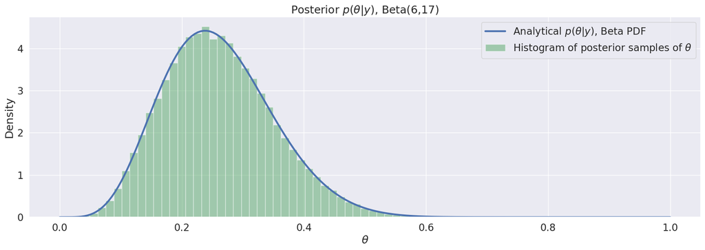

```python
# specify parameters for posterior distribution
a = 6  # shape parameter alpha of Beta posterior (successes + prior)
b = 17 # shape parameter beta of Beta posterior (failures + prior)

# The posterior is: p(θ|y) = Beta(θ | a, b)
# Equation: p(θ|y) = θ^(a-1) * (1-θ)^(b-1) / B(a, b)
# where B(a, b) is the Beta function (normalization constant)

# generate samples from the posterior
num_samples = 100000
theta_samples = beta_dist.rvs(a=a, b=b, size=num_samples)
# theta_samples.shape: (100000,)
# Each sample is a possible value of θ drawn from the posterior

# Create a grid of θ values for plotting the density
thetas = jnp.linspace(0, 1, 200)
# thetas.shape: (200,)

# Plot the analytical posterior density and the histogram of samples
fig, ax = plt.subplots(1, 1, figsize=(20, 6))

# Analytical posterior density (Beta PDF)
ax.plot(thetas, beta_dist.pdf(thetas, a=a, b=b), label=r'Analytical $p(\theta|y)$, Beta PDF')

# Histogram of posterior samples (empirical density)
ax.hist(theta_samples, bins=50, density=True, label='Histogram of posterior samples of $\\theta$', alpha=0.5, color='g')

# Axis labels and legend
ax.set(xlabel=r'$\theta$', ylabel='Density', title=fr'Posterior $p(\theta|y)$, Beta({a},{b})')
ax.legend();

# --- Shapes ---
# thetas: shape (200,)
# theta_samples: shape (100000,)

# --- Equations ---
# Posterior:      p(θ|y) = Beta(θ | a, b)
# Beta PDF:       p(θ) = θ^(a-1) * (1-θ)^(b-1) / B(a, b)
# Sampling:       θ^(i) ~ Beta(a, b),  i=1,...,num_samples
```

Using the posterior samples $\theta^{(i)} \sim p(\theta|y)$ for $i = 1, \dots, S$, we can easily **estimate** the posterior mean and variance:

```python
analytical_posterior_mean = a/(a+b)
analytical_posterior_variance = (a*b)/((a+b)**2*(a+b+1))

print(f'E[theta|D] = {jnp.mean(theta_samples):5.4f} (estimated using samples)')
print(f'E[theta|D] = {analytical_posterior_mean:5.4f} (analytical solution)\n')
print(f'V[theta|D] = {jnp.var(theta_samples):5.4f} (estimated using samples)')
print(f'V[theta|D] = {analytical_posterior_variance:5.4f} (analytical solution)')
```

```
E[theta|D] = 0.2608 (estimated using samples)
E[theta|D] = 0.2609 (analytical solution)

V[theta|D] = 0.0080 (estimated using samples)
V[theta|D] = 0.0080 (analytical solution)
```

Sampling is often easy to implement, and hence, it can also be a highly valuable method for verifying analytical results.

$$\begin{align*} P(\theta > 0.2 | \mathcal{D}) = \int_{0.2}^1 p(\theta|\mathcal{D}) \text{d} \theta = \int_0^1 \mathbb{I}\left[\theta > 0.2\right] p(\theta|\mathcal{D}) \text{d}\theta = \mathbb{E}_{p(\theta|\mathcal{D})}\left[\mathbb{I}\left[\theta > 0.2\right]\right] \approx \frac{1}{S}\sum_{i=1}^S \mathbb{I}\left[\theta^{(i)} > 0.2\right], \end{align*}$$ where $\mathbb{I}\left[\cdot\right]$ is the indicator function yielding $1$ if the condition in the brackets are true, and 0 otherwise. We will talk much more about Monte Carlo sampling later in the course, but for now, we will simply use it as tool to summarize distributions:

```python
print(f'P[theta > 0.2|D] = {jnp.mean(theta_samples > 0.2):5.4f}\t\t\t(estimated using sampling)\n')

interval = jnp.percentile(theta_samples, jnp.array([2.5, 97.5]))
print(f'95% credibility interval: [{interval[0]:4.3f}, {interval[1]:4.3f}]\t(estimated using sampling)')
```

```
P[theta > 0.2|D] = 0.7341			(estimated using sampling)

95% credibility interval: [0.108, 0.453]	(estimated using sampling)
```

##### ✨ Code explanation:

`theta_samples > 0.2` returns a boolean array.

`jnp.mean(...)` counts how many times it's True, divided by total samples.

This approximates the posterior probability that $θ>0.2$.

Generally, the larger number of samples $S$ used, the more accurate an estimate we will get. Later in the course, we will make this statement much more precise.

**Example**

A friend of yours is building a classifier for a company, and she asks for your help to evaluate the model. On an independent test set of $N = 100$ examples, the classifier made $y = 8$ errors. It is critical for the company that the error rate is below 10%. Your friend argues that the error rate is $\frac{8}{100} = 0.08$, so there no need to worry, but you are not as convinced because of the rather small test set.

Let $\theta$ represent the error rate and assume a flat Beta-prior, i.e. $a_0 = b_0 = 1$.

**Task 4.1**: Compute the posterior mean of the error rate $\theta$.

```python
N_4 = 100
y_4 = 8

a_prior_4 = 1
b_prior_4 = 1


a_post_4 = a_prior_4 + y_4
b_post_4 = b_prior_4 + N_4 - y_4

posterior_mean_4 = a_post_4 / (a_post_4 + b_post_4)
print(f'Posterior mean for N={N_4}, y={y_4}: {posterior_mean_4:.2f}')
```

```
Posterior mean for N=100, y=8: 0.09
```

**Task 4.2**: Generate $S = 10000$ samples from the posterior distribution and estimate the posterior probability of the test error being larger than $10%$. Comment on the result.

I want to estimate the probability that the error rate is above 10%, i.e.:

$$p(\theta > 0.1 | y, N)$$

This is:

$$\int_{0.1}^{1} p(\theta | y, N) d\theta = \mathbb{E}[\mathbb{I}(\theta > 0.1) | y, N] = \frac{1}{S} \sum_{i=1}^{S} \mathbb{I}(\theta_i > 0.1)$$

```
P[theta > 0.1|D] =  0.31
95% Credibility Interval: [0.042, 0.150]
```

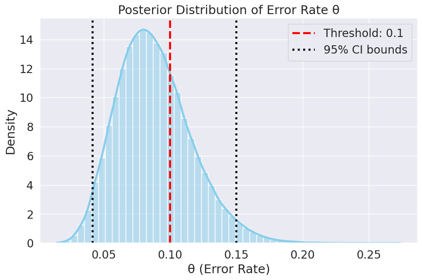

```python
# generate samples from the posterior
num_samples = 100000
theta_samples = beta_dist.rvs(a=a_post_4, b=b_post_4, size=num_samples)

print(f'P[theta > 0.1|D] = {jnp.mean(theta_samples > 0.1):5.2f}')


ci = jnp.percentile(theta_samples, jnp.array([2.5, 97.5]))
print(f"95% Credibility Interval: [{ci[0]:.3f}, {ci[1]:.3f}]")


fig, ax = plt.subplots(figsize=(10, 6))
snb.histplot(theta_samples, kde=True, stat='density', bins=50, color='skyblue')
plt.axvline(0.1, color='red', linestyle='--', label='Threshold: 0.1')
plt.axvline(ci[0], color='black', linestyle=':', label='95% CI bounds')
plt.axvline(ci[1], color='black', linestyle=':')
plt.title("Posterior Distribution of Error Rate θ")
plt.xlabel("θ (Error Rate)")
plt.ylabel("Density")
plt.legend()
plt.show()
```

# Part 5: Application to A/B testing

Suppose a website has two ads: version A and version B and that version A was shown $N_A = 947$ times and generated $y_A = 87$ clicks, whereas version B was shown $N_B = 1053$ times and generated $y_B = 101$ click.

We will now put everything together and apply it do a Bayesian analysis of the data using the Beta-binomial model.

**Task 5.1** Assuming a $\text{Beta}(\theta|2, 2)$ prior for both $\theta_A$ and $\theta_B$, plot the posterior density for both ads.

```
(0.05, 0.15)
```

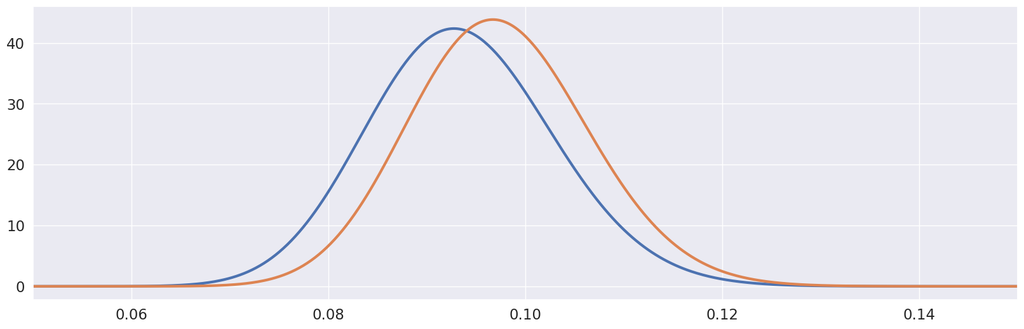

```python
N_A = 947
y_A = 87

N_B = 1053
y_B = 101

A_0, B_0 = 2, 2

A_post_A_4 = A_0 + y_A
A_post_B_4 = B_0 + N_A - y_A
B_post_A_4 = A_0 + y_B
B_post_B_4 = B_0 + N_B - y_B



# Create a grid of θ values for plotting the density
thetas = jnp.linspace(0, 1, 5000)
# thetas.shape: (5000,)

# Plot the analytical posterior density and the histogram of samples
fig, ax = plt.subplots(1, 1, figsize=(20, 6))

# Analytical posterior density (Beta PDF)
ax.plot(thetas, beta_dist.pdf(thetas, a=A_post_A_4, b=A_post_B_4), label=r'Beta PDF of version A')
ax.plot(thetas, beta_dist.pdf(thetas, a=B_post_A_4, b=B_post_B_4), label=r'Beta PDF of version B')
ax.set_xlim(0.050, 0.150)
```

**Task 5.2** Estimate the mean and a 95%-credibility interval for both ads. Use a $p(\theta) = \text{Beta}(\theta|2, 2)$ prior for both ads.

```python
add_A_post_mean = prior_and_post_mean(A_post_A_4, A_post_B_4)
add_B_post_mean = prior_and_post_mean(B_post_A_4, B_post_B_4)

print(f"Posterior mean for Ad A: {add_A_post_mean:.3f}")
print(f"Posterior mean for Ad B: {add_B_post_mean:.3f}")

from scipy.stats import beta



add_intervals = .95

cred_interval = beta.interval(0.95, A_post_A_4, A_post_B_4)
lower_A = float(cred_interval[0])
upper_A = float(cred_interval[1])
print(f"{int(add_intervals * 100)}% credible interval for Ad A: ({lower_A:.3f}, {upper_A:.3f})")

cred_interval = beta.interval(0.95, B_post_A_4, B_post_B_4)
lower_B = float(cred_interval[0])
upper_B = float(cred_interval[1])
print(f"{int(add_intervals * 100)}% credible interval for Ad B: ({lower_B:.3f}, {upper_B:.3f})")
```

```
Posterior mean for Ad A: 0.094
Posterior mean for Ad B: 0.097
95% credible interval for Ad A: (0.076, 0.113)
95% credible interval for Ad B: (0.080, 0.116)
```

**Task 5.3** Generate $S = 10000$ posterior samples for both ads and plot the histograms of both sets of samples.

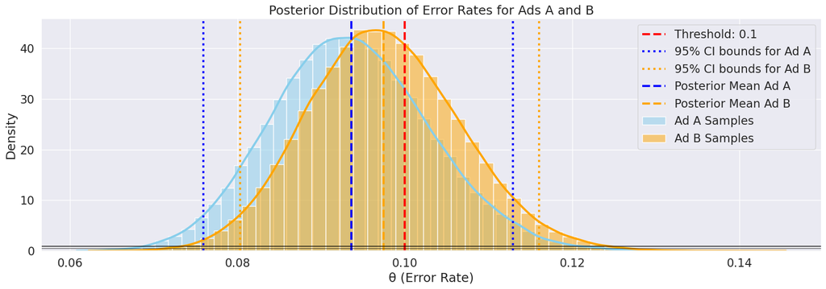

```python
num_samples = 100000


theta_A = beta_dist.rvs(a=A_post_A_4, b=A_post_B_4, size=num_samples)
theta_B = beta_dist.rvs(a=B_post_A_4, b=B_post_B_4, size=num_samples)


fig, ax = plt.subplots(1, 1, figsize=(20, 6))
snb.histplot(theta_A, kde=True, stat='density', bins=50, color='skyblue', label='Ad A Samples' , alpha=0.5)
snb.histplot(theta_B, kde=True, stat='density', bins=50, color='orange', label='Ad B Samples', alpha=0.5)
plt.axvline(0.1, color='red', linestyle='--', label='Threshold: 0.1')
plt.axvline(lower_A, color='blue', linestyle=':', label='95% CI bounds for Ad A')
plt.axvline(upper_A, color='blue', linestyle=':')
plt.axvline(lower_B, color='orange', linestyle=':', label='95% CI bounds for Ad B')
plt.axvline(upper_B, color='orange', linestyle=':')
plt.axvline(add_A_post_mean, color='blue', linestyle='--', label='Posterior Mean Ad A')
plt.axvline(add_B_post_mean, color='orange', linestyle='--', label='Posterior Mean Ad B')
plt.axhline(0, color='black', lw=0.5)
plt.axhline(1, color='black', lw=0.5)
plt.axhline(0.5, color='black', lw=0.5)
plt.axhline(0.1, color='black', lw=0.5)
plt.axhline(0.9, color='black', lw=0.5)
plt.title("Posterior Distribution of Error Rates for Ads A and B")
plt.xlabel("θ (Error Rate)")
plt.ylabel("Density")
plt.legend()
plt.show()
```

**Task 5.4** Compute posterior samples for the difference of $\theta_D = \theta_B - \theta_A$ and visualize the histogram

[figure not shown]

```python
theta_D = add_b_samples - theta_A

fig, ax = plt.subplots(1, 1, figsize=(10, 6))
snb.histplot(theta_D, kde=True, stat='density', bins=50, color='lightpink', label='Difference Samples', alpha=0.5)
plt.axvline(0, color='black', linestyle='--', label='Zero Difference')
plt.axvline(jnp.mean(theta_D), color='blue', linestyle='--', label='Mean Difference')
plt.axvline(jnp.percentile(theta_D, 2.5), color='blue', linestyle=':', label='2.5% Quantile')
plt.axvline(jnp.percentile(theta_D, 97.5), color='blue', linestyle=':', label='97.5% Quantile')
plt.title("Difference in Posterior Distributions of Ads A and B")
plt.xlabel("θ_D (Difference in Error Rates)")
plt.ylabel("Density")
plt.legend()
plt.show()
```

**Task 5.5** Compute the posterior mean and 95% credibility interval for $\theta_D$ using the posterior samples

```python
print(f"Posterior mean of difference: {jnp.mean(theta_D):.3f}")
print(f"Posterior 95% CI of difference: [{jnp.percentile(theta_D, 2.5):.3f}, {jnp.percentile(theta_D, 97.5):.3f}]")
```

```
Posterior mean of difference: 0.004
Posterior 95% CI of difference: [-0.022, 0.030]
```

**Task 5.6** What is the posterior probability that the click-rate of version B is larger than click-rate of version A?

```python
print(f'P(theta_B > theta_A|D) = {jnp.mean(theta_B > theta_A):4.3f} (estimated using samples)')
```

```
P(theta_B > theta_A|D) = 0.619 (estimated using samples)
```